# Rainfallprediction

Internship on "Full Stack Data Science" at InfraBIM Techno Solutions DS-09: Project - Rainfall prediction of Telangana

Internship Reg. No.:1027

Name:S.LAVAN KARTHIK

Date:12/01/2023

Other Team Members: (Reg.No. - Name)

1.1001-PEDDIREDDY.VIVEK REDDY

2.3048-ETTIREDDY SUMANTH REDDY

3.3136-KOLLIBETTI GANESH

**Rainfall Prediction**

[figure not shown]

**Table of Contents**

1.Introduction

2.Import Packages

3.Load Dataset

4.Exploratory Data Analysis (EDA)

5.Model Selection and Evaluation

6.Create Pickle file

7.Conclusion

8.References

**Introduction:**

Rainfall prediction remains a serious concern and has attracted the attentionof governments, industries, risk management entities, as well as the scientiﬁccommunity. Rainfall is a climatic factor that aﬀects many human activities likeagricultural production, construction, power generation, forestry and tourism,among others.To this extent, rainfall prediction is essential since this variable is the one with the highest correlation with adverse natural events such as landslides,ﬂooding,mass movements and avalanches.These incidents have aﬀected society for years.Therefore, having an appropriate approach for rain-fall prediction makes it possible to take preventive and mitigation measures forthese natural phenomena.

Problem Statement:TO PREDICT THE RAINFALL IN TELANGANA

**2.Import Packages**

```python
# Import warnings
import warnings
warnings.filterwarnings('ignore')
```

```python
#1.Importing the required packages
import numpy as np
import pandas as pd
import matplotlib.pyplot as plt
import seaborn as sns
```

**3.Load Dataset**

```python
#Load Dataset
df=pd.read_csv("https://internship-257.s3.amazonaws.com/rainfall_india_1901-2015.csv")
df
```

|  | SUBDIVISION | YEAR | JAN | FEB | MAR | APR | MAY | JUN | JUL | AUG | SEP | OCT | NOV | DEC | ANNUAL | Jan-Feb | Mar-May | Jun-Sep | Oct-Dec |
| --- | --- | --- | --- | --- | --- | --- | --- | --- | --- | --- | --- | --- | --- | --- | --- | --- | --- | --- | --- |
| 0 | ANDAMAN & NICOBAR ISLANDS | 1901 | 49.2 | 87.1 | 29.2 | 2.3 | 528.8 | 517.5 | 365.1 | 481.1 | 332.6 | 388.5 | 558.2 | 33.6 | 3373.2 | 136.3 | 560.3 | 1696.3 | 980.3 |
| 1 | ANDAMAN & NICOBAR ISLANDS | 1902 | 0.0 | 159.8 | 12.2 | 0.0 | 446.1 | 537.1 | 228.9 | 753.7 | 666.2 | 197.2 | 359.0 | 160.5 | 3520.7 | 159.8 | 458.3 | 2185.9 | 716.7 |
| 2 | ANDAMAN & NICOBAR ISLANDS | 1903 | 12.7 | 144.0 | 0.0 | 1.0 | 235.1 | 479.9 | 728.4 | 326.7 | 339.0 | 181.2 | 284.4 | 225.0 | 2957.4 | 156.7 | 236.1 | 1874.0 | 690.6 |
| 3 | ANDAMAN & NICOBAR ISLANDS | 1904 | 9.4 | 14.7 | 0.0 | 202.4 | 304.5 | 495.1 | 502.0 | 160.1 | 820.4 | 222.2 | 308.7 | 40.1 | 3079.6 | 24.1 | 506.9 | 1977.6 | 571.0 |
| 4 | ANDAMAN & NICOBAR ISLANDS | 1905 | 1.3 | 0.0 | 3.3 | 26.9 | 279.5 | 628.7 | 368.7 | 330.5 | 297.0 | 260.7 | 25.4 | 344.7 | 2566.7 | 1.3 | 309.7 | 1624.9 | 630.8 |
| ... | ... | ... | ... | ... | ... | ... | ... | ... | ... | ... | ... | ... | ... | ... | ... | ... | ... | ... | ... |
| 4111 | LAKSHADWEEP | 2011 | 5.1 | 2.8 | 3.1 | 85.9 | 107.2 | 153.6 | 350.2 | 254.0 | 255.2 | 117.4 | 184.3 | 14.9 | 1533.7 | 7.9 | 196.2 | 1013.0 | 316.6 |
| 4112 | LAKSHADWEEP | 2012 | 19.2 | 0.1 | 1.6 | 76.8 | 21.2 | 327.0 | 231.5 | 381.2 | 179.8 | 145.9 | 12.4 | 8.8 | 1405.5 | 19.3 | 99.6 | 1119.5 | 167.1 |
| 4113 | LAKSHADWEEP | 2013 | 26.2 | 34.4 | 37.5 | 5.3 | 88.3 | 426.2 | 296.4 | 154.4 | 180.0 | 72.8 | 78.1 | 26.7 | 1426.3 | 60.6 | 131.1 | 1057.0 | 177.6 |
| 4114 | LAKSHADWEEP | 2014 | 53.2 | 16.1 | 4.4 | 14.9 | 57.4 | 244.1 | 116.1 | 466.1 | 132.2 | 169.2 | 59.0 | 62.3 | 1395.0 | 69.3 | 76.7 | 958.5 | 290.5 |
| 4115 | LAKSHADWEEP | 2015 | 2.2 | 0.5 | 3.7 | 87.1 | 133.1 | 296.6 | 257.5 | 146.4 | 160.4 | 165.4 | 231.0 | 159.0 | 1642.9 | 2.7 | 223.9 | 860.9 | 555.4 |

4116 rows × 19 columns

**4.Exploratory Data Analysis (EDA)**

```python
df.info()
```

```
<class 'pandas.core.frame.DataFrame'>
RangeIndex: 4116 entries, 0 to 4115
Data columns (total 19 columns):
 #   Column       Non-Null Count  Dtype
---  ------       --------------  -----
 0   SUBDIVISION  4116 non-null   object
 1   YEAR         4116 non-null   int64
 2   JAN          4112 non-null   float64
 3   FEB          4113 non-null   float64
 4   MAR          4110 non-null   float64
 5   APR          4112 non-null   float64
 6   MAY          4113 non-null   float64
 7   JUN          4111 non-null   float64
 8   JUL          4109 non-null   float64
 9   AUG          4112 non-null   float64
 10  SEP          4110 non-null   float64
 11  OCT          4109 non-null   float64
 12  NOV          4105 non-null   float64
 13  DEC          4106 non-null   float64
 14  ANNUAL       4090 non-null   float64
 15  Jan-Feb      4110 non-null   float64
 16  Mar-May      4107 non-null   float64
 17  Jun-Sep      4106 non-null   float64
 18  Oct-Dec      4103 non-null   float64
dtypes: float64(17), int64(1), object(1)
memory usage: 611.1+ KB
```

```python
#size of dataset
df.shape
```

```
(4116, 19)
```

```python
#checking of null values
df.isnull().sum()
```

```
SUBDIVISION     0
YEAR            0
JAN             4
FEB             3
MAR             6
APR             4
MAY             3
JUN             5
JUL             7
AUG             4
SEP             6
OCT             7
NOV            11
DEC            10
ANNUAL         26
Jan-Feb         6
Mar-May         9
Jun-Sep        10
Oct-Dec        13
dtype: int64
```

```python
df.duplicated().sum()
```

```
0
```

```python
df['SUBDIVISION'].value_counts()
```

```
WEST MADHYA PRADESH                   115
EAST RAJASTHAN                        115
COASTAL KARNATAKA                     115
TAMIL NADU                            115
RAYALSEEMA                            115
TELANGANA                             115
COASTAL ANDHRA PRADESH                115
CHHATTISGARH                          115
VIDARBHA                              115
MATATHWADA                            115
MADHYA MAHARASHTRA                    115
KONKAN & GOA                          115
SAURASHTRA & KUTCH                    115
GUJARAT REGION                        115
EAST MADHYA PRADESH                   115
KERALA                                115
WEST RAJASTHAN                        115
SOUTH INTERIOR KARNATAKA              115
JAMMU & KASHMIR                       115
HIMACHAL PRADESH                      115
PUNJAB                                115
HARYANA DELHI & CHANDIGARH            115
UTTARAKHAND                           115
WEST UTTAR PRADESH                    115
EAST UTTAR PRADESH                    115
BIHAR                                 115
JHARKHAND                             115
ORISSA                                115
GANGETIC WEST BENGAL                  115
SUB HIMALAYAN WEST BENGAL & SIKKIM    115
NAGA MANI MIZO TRIPURA                115
ASSAM & MEGHALAYA                     115
NORTH INTERIOR KARNATAKA              115
LAKSHADWEEP                           114
ANDAMAN & NICOBAR ISLANDS             110
ARUNACHAL PRADESH                      97
Name: SUBDIVISION, dtype: int64
```

```python
#mean of the dataset
df.mean()
```

```
YEAR       1958.218659
JAN          18.957320
FEB          21.805325
MAR          27.359197
APR          43.127432
MAY          85.745417
JUN         230.234444
JUL         347.214334
AUG         290.263497
SEP         197.361922
OCT          95.507009
NOV          39.866163
DEC          18.870580
ANNUAL     1411.008900
Jan-Feb      40.747786
Mar-May     155.901753
Jun-Sep    1064.724769
Oct-Dec     154.100487
dtype: float64
```

```python
# filling na values with mean
df = df.fillna(df.mean())
df
```

|  | SUBDIVISION | YEAR | JAN | FEB | MAR | APR | MAY | JUN | JUL | AUG | SEP | OCT | NOV | DEC | ANNUAL | Jan-Feb | Mar-May | Jun-Sep | Oct-Dec |
| --- | --- | --- | --- | --- | --- | --- | --- | --- | --- | --- | --- | --- | --- | --- | --- | --- | --- | --- | --- |
| 0 | ANDAMAN & NICOBAR ISLANDS | 1901 | 49.2 | 87.1 | 29.2 | 2.3 | 528.8 | 517.5 | 365.1 | 481.1 | 332.6 | 388.5 | 558.2 | 33.6 | 3373.2 | 136.3 | 560.3 | 1696.3 | 980.3 |
| 1 | ANDAMAN & NICOBAR ISLANDS | 1902 | 0.0 | 159.8 | 12.2 | 0.0 | 446.1 | 537.1 | 228.9 | 753.7 | 666.2 | 197.2 | 359.0 | 160.5 | 3520.7 | 159.8 | 458.3 | 2185.9 | 716.7 |
| 2 | ANDAMAN & NICOBAR ISLANDS | 1903 | 12.7 | 144.0 | 0.0 | 1.0 | 235.1 | 479.9 | 728.4 | 326.7 | 339.0 | 181.2 | 284.4 | 225.0 | 2957.4 | 156.7 | 236.1 | 1874.0 | 690.6 |
| 3 | ANDAMAN & NICOBAR ISLANDS | 1904 | 9.4 | 14.7 | 0.0 | 202.4 | 304.5 | 495.1 | 502.0 | 160.1 | 820.4 | 222.2 | 308.7 | 40.1 | 3079.6 | 24.1 | 506.9 | 1977.6 | 571.0 |
| 4 | ANDAMAN & NICOBAR ISLANDS | 1905 | 1.3 | 0.0 | 3.3 | 26.9 | 279.5 | 628.7 | 368.7 | 330.5 | 297.0 | 260.7 | 25.4 | 344.7 | 2566.7 | 1.3 | 309.7 | 1624.9 | 630.8 |
| ... | ... | ... | ... | ... | ... | ... | ... | ... | ... | ... | ... | ... | ... | ... | ... | ... | ... | ... | ... |
| 4111 | LAKSHADWEEP | 2011 | 5.1 | 2.8 | 3.1 | 85.9 | 107.2 | 153.6 | 350.2 | 254.0 | 255.2 | 117.4 | 184.3 | 14.9 | 1533.7 | 7.9 | 196.2 | 1013.0 | 316.6 |
| 4112 | LAKSHADWEEP | 2012 | 19.2 | 0.1 | 1.6 | 76.8 | 21.2 | 327.0 | 231.5 | 381.2 | 179.8 | 145.9 | 12.4 | 8.8 | 1405.5 | 19.3 | 99.6 | 1119.5 | 167.1 |
| 4113 | LAKSHADWEEP | 2013 | 26.2 | 34.4 | 37.5 | 5.3 | 88.3 | 426.2 | 296.4 | 154.4 | 180.0 | 72.8 | 78.1 | 26.7 | 1426.3 | 60.6 | 131.1 | 1057.0 | 177.6 |
| 4114 | LAKSHADWEEP | 2014 | 53.2 | 16.1 | 4.4 | 14.9 | 57.4 | 244.1 | 116.1 | 466.1 | 132.2 | 169.2 | 59.0 | 62.3 | 1395.0 | 69.3 | 76.7 | 958.5 | 290.5 |
| 4115 | LAKSHADWEEP | 2015 | 2.2 | 0.5 | 3.7 | 87.1 | 133.1 | 296.6 | 257.5 | 146.4 | 160.4 | 165.4 | 231.0 | 159.0 | 1642.9 | 2.7 | 223.9 | 860.9 | 555.4 |

4116 rows × 19 columns

```python
df.isnull().any()
```

```
SUBDIVISION    False
YEAR           False
JAN            False
FEB            False
MAR            False
APR            False
MAY            False
JUN            False
JUL            False
AUG            False
SEP            False
OCT            False
NOV            False
DEC            False
ANNUAL         False
Jan-Feb        False
Mar-May        False
Jun-Sep        False
Oct-Dec        False
dtype: bool
```

```python
df.YEAR.unique()
```

```
array([1901, 1902, 1903, 1904, 1905, 1906, 1907, 1908, 1910, 1911, 1912,
       1913, 1914, 1915, 1916, 1917, 1918, 1919, 1920, 1921, 1922, 1923,
       1924, 1925, 1926, 1927, 1928, 1929, 1930, 1931, 1932, 1933, 1934,
       1935, 1936, 1937, 1938, 1939, 1940, 1941, 1942, 1946, 1947, 1949,
       1950, 1951, 1952, 1953, 1954, 1955, 1956, 1957, 1958, 1959, 1960,
       1961, 1962, 1963, 1964, 1965, 1966, 1967, 1968, 1969, 1970, 1971,
       1972, 1973, 1974, 1975, 1976, 1977, 1978, 1979, 1980, 1981, 1982,
       1983, 1984, 1985, 1986, 1987, 1988, 1989, 1990, 1991, 1992, 1993,
       1994, 1995, 1996, 1997, 1998, 1999, 2000, 2001, 2002, 2003, 2004,
       2005, 2006, 2007, 2008, 2009, 2010, 2011, 2012, 2013, 2014, 2015,
       1943, 1944, 1945, 1948, 1909])
```

```python
df.describe()
```

|  | YEAR | JAN | FEB | MAR | APR | MAY | JUN | JUL | AUG | SEP | OCT | NOV | DEC | ANNUAL | Jan-Feb | Mar-May | Jun-Sep | Oct-Dec |
| --- | --- | --- | --- | --- | --- | --- | --- | --- | --- | --- | --- | --- | --- | --- | --- | --- | --- | --- |
| count | 4116.000000 | 4116.000000 | 4116.000000 | 4116.000000 | 4116.000000 | 4116.000000 | 4116.000000 | 4116.000000 | 4116.000000 | 4116.000000 | 4116.000000 | 4116.000000 | 4116.000000 | 4116.000000 | 4116.000000 | 4116.000000 | 4116.000000 | 4116.000000 |
| mean | 1958.218659 | 18.957320 | 21.805325 | 27.359197 | 43.127432 | 85.745417 | 230.234444 | 347.214334 | 290.263497 | 197.361922 | 95.507009 | 39.866163 | 18.870580 | 1411.008900 | 40.747786 | 155.901753 | 1064.724769 | 154.100487 |
| std | 33.140898 | 33.569044 | 35.896396 | 46.925176 | 67.798192 | 123.189974 | 234.568120 | 269.310313 | 188.678707 | 135.309591 | 99.434452 | 68.593545 | 42.318098 | 900.986632 | 59.265023 | 201.096692 | 706.881054 | 166.678751 |
| min | 1901.000000 | 0.000000 | 0.000000 | 0.000000 | 0.000000 | 0.000000 | 0.400000 | 0.000000 | 0.000000 | 0.100000 | 0.000000 | 0.000000 | 0.000000 | 62.300000 | 0.000000 | 0.000000 | 57.400000 | 0.000000 |
| 25% | 1930.000000 | 0.600000 | 0.600000 | 1.000000 | 3.000000 | 8.600000 | 70.475000 | 175.900000 | 156.150000 | 100.600000 | 14.600000 | 0.700000 | 0.100000 | 806.450000 | 4.100000 | 24.200000 | 574.375000 | 34.200000 |
| 50% | 1958.000000 | 6.000000 | 6.700000 | 7.900000 | 15.700000 | 36.700000 | 138.900000 | 284.900000 | 259.500000 | 174.100000 | 65.750000 | 9.700000 | 3.100000 | 1125.450000 | 19.300000 | 75.200000 | 882.250000 | 98.800000 |
| 75% | 1987.000000 | 22.125000 | 26.800000 | 31.225000 | 49.825000 | 96.825000 | 304.950000 | 418.225000 | 377.725000 | 265.725000 | 148.300000 | 45.825000 | 17.700000 | 1635.100000 | 50.300000 | 196.900000 | 1287.550000 | 212.600000 |
| max | 2015.000000 | 583.700000 | 403.500000 | 605.600000 | 595.100000 | 1168.600000 | 1609.900000 | 2362.800000 | 1664.600000 | 1222.000000 | 948.300000 | 648.900000 | 617.500000 | 6331.100000 | 699.500000 | 1745.800000 | 4536.900000 | 1252.500000 |

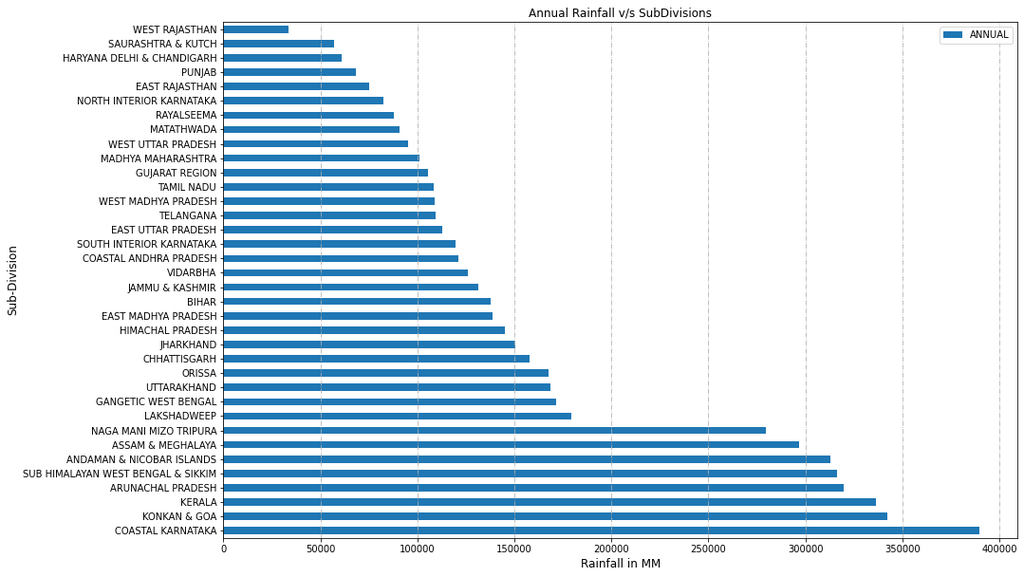

```python
df[["SUBDIVISION","ANNUAL"]].groupby("SUBDIVISION").sum().sort_values(by='ANNUAL',ascending=False).plot(kind='barh',stacked=True,figsize=(15,10))
plt.xlabel("Rainfall in MM",size=12)
plt.ylabel("Sub-Division",size=12)
plt.title("Annual Rainfall v/s SubDivisions")
plt.grid(axis="x",linestyle="-.")
plt.show()
```

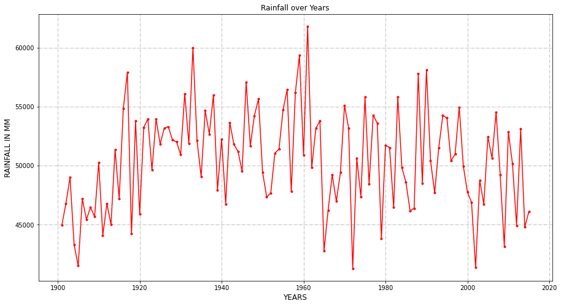

```python
plt.figure(figsize=(15,8))
df.groupby("YEAR").sum()['ANNUAL'].plot(kind="line",color="r",marker=".")
plt.xlabel("YEARS",size=12)
plt.ylabel("RAINFALL IN MM",size=12)
plt.grid(axis="both",linestyle="-.")
plt.title("Rainfall over Years")
plt.show()
```

```python
# Analysis of rainfall data of tamil nadu
TS = df.loc[((df['SUBDIVISION'] == 'TELANGANA'))]
TS
```

|  | SUBDIVISION | YEAR | JAN | FEB | MAR | APR | MAY | JUN | JUL | AUG | SEP | OCT | NOV | DEC | ANNUAL | Jan-Feb | Mar-May | Jun-Sep | Oct-Dec |
| --- | --- | --- | --- | --- | --- | --- | --- | --- | --- | --- | --- | --- | --- | --- | --- | --- | --- | --- | --- |
| 3197 | TELANGANA | 1901 | 6.9 | 41.8 | 7.8 | 45.2 | 22.0 | 123.6 | 237.8 | 177.2 | 77.7 | 75.5 | 12.2 | 0.0 | 827.7 | 48.7 | 75.0 | 616.4 | 87.7 |
| 3198 | TELANGANA | 1902 | 0.0 | 0.0 | 0.2 | 10.7 | 7.3 | 52.4 | 146.3 | 142.8 | 190.5 | 41.7 | 31.2 | 7.3 | 630.4 | 0.0 | 18.2 | 532.0 | 80.2 |
| 3199 | TELANGANA | 1903 | 12.9 | 4.6 | 0.0 | 9.9 | 40.7 | 99.2 | 505.2 | 246.7 | 191.9 | 155.8 | 15.5 | 1.1 | 1283.4 | 17.5 | 50.5 | 1042.9 | 172.4 |
| 3200 | TELANGANA | 1904 | 0.0 | 0.0 | 10.8 | 0.8 | 14.7 | 104.2 | 139.5 | 50.0 | 162.3 | 44.4 | 0.0 | 0.0 | 526.7 | 0.0 | 26.3 | 456.0 | 44.4 |
| 3201 | TELANGANA | 1905 | 0.0 | 4.3 | 12.8 | 27.6 | 32.2 | 129.5 | 82.4 | 237.3 | 179.1 | 19.6 | 0.0 | 0.0 | 724.9 | 4.3 | 72.6 | 628.4 | 19.6 |
| ... | ... | ... | ... | ... | ... | ... | ... | ... | ... | ... | ... | ... | ... | ... | ... | ... | ... | ... | ... |
| 3307 | TELANGANA | 2011 | 0.0 | 11.9 | 2.6 | 25.6 | 9.3 | 83.9 | 268.2 | 225.9 | 107.6 | 13.9 | 4.2 | 0.0 | 753.1 | 11.9 | 37.4 | 685.6 | 18.1 |
| 3308 | TELANGANA | 2012 | 6.7 | 0.0 | 0.2 | 14.0 | 8.4 | 124.4 | 300.3 | 229.9 | 202.4 | 83.6 | 38.7 | 0.0 | 1008.6 | 6.7 | 22.6 | 857.0 | 122.3 |
| 3309 | TELANGANA | 2013 | 2.4 | 29.0 | 0.2 | 24.4 | 8.5 | 213.4 | 453.8 | 230.6 | 161.4 | 205.9 | 16.4 | 2.7 | 1348.7 | 31.4 | 33.0 | 1059.2 | 225.0 |
| 3310 | TELANGANA | 2014 | 0.2 | 2.9 | 58.3 | 10.3 | 73.3 | 62.3 | 146.0 | 205.2 | 146.8 | 29.6 | 10.8 | 0.7 | 746.4 | 3.1 | 141.9 | 560.2 | 41.0 |
| 3311 | TELANGANA | 2015 | 17.5 | 0.0 | 43.0 | 65.7 | 23.3 | 266.9 | 104.4 | 160.5 | 158.3 | 15.6 | 0.3 | 1.7 | 857.3 | 17.5 | 132.0 | 690.1 | 17.6 |

115 rows × 19 columns

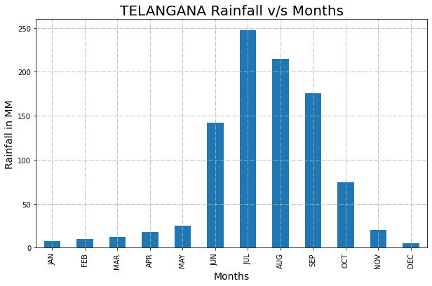

```python
plt.figure(figsize=(10,6))
TS[['JAN', 'FEB', 'MAR', 'APR','MAY', 'JUN','JUL','AUG', 'SEP', 'OCT','NOV','DEC']].mean().plot(kind="bar",width=0.5,linewidth=2)
plt.title("TELANGANA Rainfall v/s Months",size=20)
plt.xlabel("Months",size=14)
plt.ylabel("Rainfall in MM",size=14)
plt.grid(axis="both",linestyle="-.")
plt.show()
```

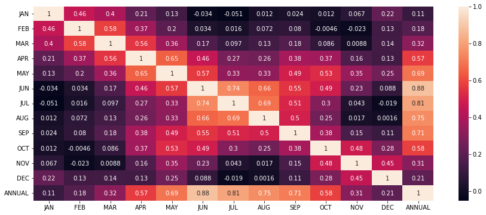

```python
# correlation b/w each numeric attribute
plt.figure(figsize=(15,6))
sns.heatmap(df[['JAN','FEB','MAR','APR','MAY','JUN','JUL','AUG','SEP','OCT','NOV','DEC','ANNUAL']].corr(),annot=True)
plt.show()
```

```python
df["SUBDIVISION"].nunique()
```

```
36
```

```python
group = df.groupby('SUBDIVISION')['YEAR','JAN','FEB','MAR','APR','MAY','JUN','JUL','AUG','SEP','OCT','NOV','DEC']
df=group.get_group(('TELANGANA'))
df
```

|  | YEAR | JAN | FEB | MAR | APR | MAY | JUN | JUL | AUG | SEP | OCT | NOV | DEC |
| --- | --- | --- | --- | --- | --- | --- | --- | --- | --- | --- | --- | --- | --- |
| 3197 | 1901 | 6.9 | 41.8 | 7.8 | 45.2 | 22.0 | 123.6 | 237.8 | 177.2 | 77.7 | 75.5 | 12.2 | 0.0 |
| 3198 | 1902 | 0.0 | 0.0 | 0.2 | 10.7 | 7.3 | 52.4 | 146.3 | 142.8 | 190.5 | 41.7 | 31.2 | 7.3 |
| 3199 | 1903 | 12.9 | 4.6 | 0.0 | 9.9 | 40.7 | 99.2 | 505.2 | 246.7 | 191.9 | 155.8 | 15.5 | 1.1 |
| 3200 | 1904 | 0.0 | 0.0 | 10.8 | 0.8 | 14.7 | 104.2 | 139.5 | 50.0 | 162.3 | 44.4 | 0.0 | 0.0 |
| 3201 | 1905 | 0.0 | 4.3 | 12.8 | 27.6 | 32.2 | 129.5 | 82.4 | 237.3 | 179.1 | 19.6 | 0.0 | 0.0 |
| ... | ... | ... | ... | ... | ... | ... | ... | ... | ... | ... | ... | ... | ... |
| 3307 | 2011 | 0.0 | 11.9 | 2.6 | 25.6 | 9.3 | 83.9 | 268.2 | 225.9 | 107.6 | 13.9 | 4.2 | 0.0 |
| 3308 | 2012 | 6.7 | 0.0 | 0.2 | 14.0 | 8.4 | 124.4 | 300.3 | 229.9 | 202.4 | 83.6 | 38.7 | 0.0 |
| 3309 | 2013 | 2.4 | 29.0 | 0.2 | 24.4 | 8.5 | 213.4 | 453.8 | 230.6 | 161.4 | 205.9 | 16.4 | 2.7 |
| 3310 | 2014 | 0.2 | 2.9 | 58.3 | 10.3 | 73.3 | 62.3 | 146.0 | 205.2 | 146.8 | 29.6 | 10.8 | 0.7 |
| 3311 | 2015 | 17.5 | 0.0 | 43.0 | 65.7 | 23.3 | 266.9 | 104.4 | 160.5 | 158.3 | 15.6 | 0.3 | 1.7 |

115 rows × 13 columns

```python
df=df.melt(['YEAR']).reset_index()
df
```

|  | index | YEAR | variable | value |
| --- | --- | --- | --- | --- |
| 0 | 0 | 1901 | JAN | 6.9 |
| 1 | 1 | 1902 | JAN | 0.0 |
| 2 | 2 | 1903 | JAN | 12.9 |
| 3 | 3 | 1904 | JAN | 0.0 |
| 4 | 4 | 1905 | JAN | 0.0 |
| ... | ... | ... | ... | ... |
| 1375 | 1375 | 2011 | DEC | 0.0 |
| 1376 | 1376 | 2012 | DEC | 0.0 |
| 1377 | 1377 | 2013 | DEC | 2.7 |
| 1378 | 1378 | 2014 | DEC | 0.7 |
| 1379 | 1379 | 2015 | DEC | 1.7 |

1380 rows × 4 columns

```python
df= df[['YEAR','variable','value']].reset_index().sort_values(by=['YEAR','index'])
df
```

|  | index | YEAR | variable | value |
| --- | --- | --- | --- | --- |
| 0 | 0 | 1901 | JAN | 6.9 |
| 115 | 115 | 1901 | FEB | 41.8 |
| 230 | 230 | 1901 | MAR | 7.8 |
| 345 | 345 | 1901 | APR | 45.2 |
| 460 | 460 | 1901 | MAY | 22.0 |
| ... | ... | ... | ... | ... |
| 919 | 919 | 2015 | AUG | 160.5 |
| 1034 | 1034 | 2015 | SEP | 158.3 |
| 1149 | 1149 | 2015 | OCT | 15.6 |
| 1264 | 1264 | 2015 | NOV | 0.3 |
| 1379 | 1379 | 2015 | DEC | 1.7 |

1380 rows × 4 columns

```python
df.YEAR.unique()
```

```
array([1901, 1902, 1903, 1904, 1905, 1906, 1907, 1908, 1909, 1910, 1911,
       1912, 1913, 1914, 1915, 1916, 1917, 1918, 1919, 1920, 1921, 1922,
       1923, 1924, 1925, 1926, 1927, 1928, 1929, 1930, 1931, 1932, 1933,
       1934, 1935, 1936, 1937, 1938, 1939, 1940, 1941, 1942, 1943, 1944,
       1945, 1946, 1947, 1948, 1949, 1950, 1951, 1952, 1953, 1954, 1955,
       1956, 1957, 1958, 1959, 1960, 1961, 1962, 1963, 1964, 1965, 1966,
       1967, 1968, 1969, 1970, 1971, 1972, 1973, 1974, 1975, 1976, 1977,
       1978, 1979, 1980, 1981, 1982, 1983, 1984, 1985, 1986, 1987, 1988,
       1989, 1990, 1991, 1992, 1993, 1994, 1995, 1996, 1997, 1998, 1999,
       2000, 2001, 2002, 2003, 2004, 2005, 2006, 2007, 2008, 2009, 2010,
       2011, 2012, 2013, 2014, 2015])
```

```python
df.columns=['Index','Year','Month','Avg_Rainfall']
df
```

|  | Index | Year | Month | Avg_Rainfall |
| --- | --- | --- | --- | --- |
| 0 | 0 | 1901 | JAN | 6.9 |
| 115 | 115 | 1901 | FEB | 41.8 |
| 230 | 230 | 1901 | MAR | 7.8 |
| 345 | 345 | 1901 | APR | 45.2 |
| 460 | 460 | 1901 | MAY | 22.0 |
| ... | ... | ... | ... | ... |
| 919 | 919 | 2015 | AUG | 160.5 |
| 1034 | 1034 | 2015 | SEP | 158.3 |
| 1149 | 1149 | 2015 | OCT | 15.6 |
| 1264 | 1264 | 2015 | NOV | 0.3 |
| 1379 | 1379 | 2015 | DEC | 1.7 |

1380 rows × 4 columns

```python
Month_map={'JAN':1,'FEB':2,'MAR' :3,'APR':4,'MAY':5,'JUN':6,'JUL':7,'AUG':8,'SEP':9,
   'OCT':10,'NOV':11,'DEC':12}
df['Month']=df['Month'].map(Month_map)
df
```

|  | Index | Year | Month | Avg_Rainfall |
| --- | --- | --- | --- | --- |
| 0 | 0 | 1901 | 1 | 6.9 |
| 115 | 115 | 1901 | 2 | 41.8 |
| 230 | 230 | 1901 | 3 | 7.8 |
| 345 | 345 | 1901 | 4 | 45.2 |
| 460 | 460 | 1901 | 5 | 22.0 |
| ... | ... | ... | ... | ... |
| 919 | 919 | 2015 | 8 | 160.5 |
| 1034 | 1034 | 2015 | 9 | 158.3 |
| 1149 | 1149 | 2015 | 10 | 15.6 |
| 1264 | 1264 | 2015 | 11 | 0.3 |
| 1379 | 1379 | 2015 | 12 | 1.7 |

1380 rows × 4 columns

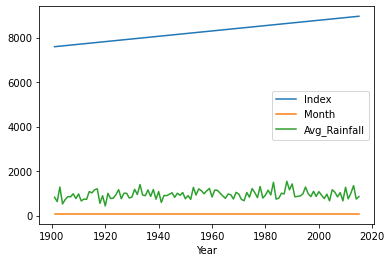

```python
df.groupby("Year").sum().plot()
plt.show()
```

```python
x=np.asanyarray(df[['Year','Month']]).astype('int')
y=np.asanyarray(df['Avg_Rainfall']).astype('int')
print(x.shape)
print(y.shape)
```

```
(1380, 2)
(1380,)
```

```python
# splitting the dataset into training and testing in the ratio 80:20
from sklearn.model_selection import train_test_split
x_train, x_test, y_train, y_test = train_test_split(x, y, test_size=0.2, random_state=10)
```

**5.Model Selection and Evaluation**

```python
#Linear Regression
from sklearn.linear_model import LinearRegression
LR = LinearRegression()
LR.fit(x_train,y_train)
```

```
LinearRegression()
```

```python
LR.score(x,y)
```

```
0.05618316558891612
```

```python
#Logistic Regression
from sklearn.linear_model import LogisticRegression
lr= LogisticRegression()
lr.fit(x_train,y_train)
```

```
LogisticRegression()
```

```python
lr.score(x,y)
```

```
0.16594202898550725
```

```python
#Decision Tree
from sklearn.tree import DecisionTreeClassifier
dtc=DecisionTreeClassifier()
dtc.fit(x_train,y_train)
```

```
DecisionTreeClassifier()
```

```python
dtc.score(x_test,y_test)
```

```
0.057971014492753624
```

```python
#Random forest
from sklearn.ensemble import RandomForestRegressor
rfr = RandomForestRegressor()
rfr.fit(x_train, y_train)
```

```
RandomForestRegressor()
```

```python
rfr.score(x,y)
```

```
0.8863697065588295
```

**6.Create Pickle file**

```python
#import the model
import pickle
pickle.dump(rfr,open("rfr.pkl","wb"))
```

```python
model = pickle.load(open("rfr.pkl","rb"))
model
```

```
RandomForestRegressor()
```

```python
rfr.predict([[2016,11]])
```

```
array([11.18])
```

```python
rfr.predict([[2011,8]])
```

```
array([228.96])
```

**8.References:**

1]Pandas Documentation. Available: https://pandas.pydata.org/ pandas-docs/stable/reference/api/pandas.get_dummies.html

2] Sckit-Learn Documentation Available: https://scikit-learn.org/ stable/modules/generated/sklearn.feature_extraction.FeatureHasher. html

3]Feature Selection Techniques in Machine Learning with Python Available: https://towardsdatascience.com/ feature-selection-techniques-in-machine-learning-with-python-f24e7da3f36e

4]Evaluate your Machine Learning Algorithm Available: https://towardsdatascience.com/ metrics-to-evaluate-your-machine-learning-algorithm-f10ba6e38234